# Day 2: The Social Relations Model and Blockmodels

**The built-in GOF.** We hand-rolled `calc_gof()` so the scorecard’s numbers stay comparable across the whole course, but NetMix keeps its own score:

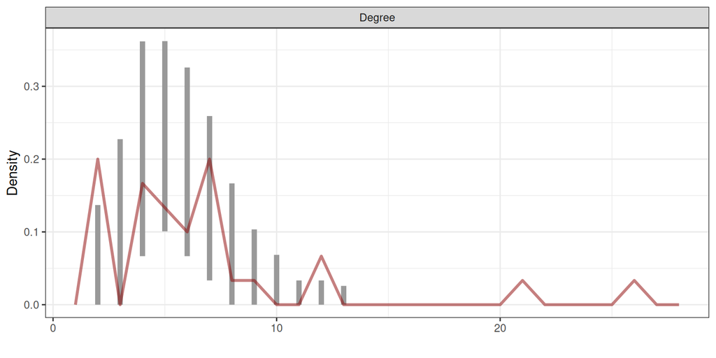

NetMix’s gof(): degree distributions of simulated networks (grey bars) against the observed network (red line). The observed right tail, the handful of very active groups, sits where the simulations put no mass at all. That is the actor_sd miss from the scorecard, in the package’s own plot.

```r
set.seed(6886)
gof(blocks_5, gof_stat = "Degree", samples = 50)
```

**Covariate effects on the probability scale.** The dyadic coefficients live on the log-odds scale; `covFX()` turns a covariate shift into per-dyad changes in tie probability (it works on the monadic covariates. For dyadic ones, use `predict()` on modified data):

```r
fx <- covFX(blocks_5, cov = "size_actor1", shift = 1)
round(fx[["Overall Avg. Effect of size_actor1"]], 4)
```

```
#> [1] -0.0012
```

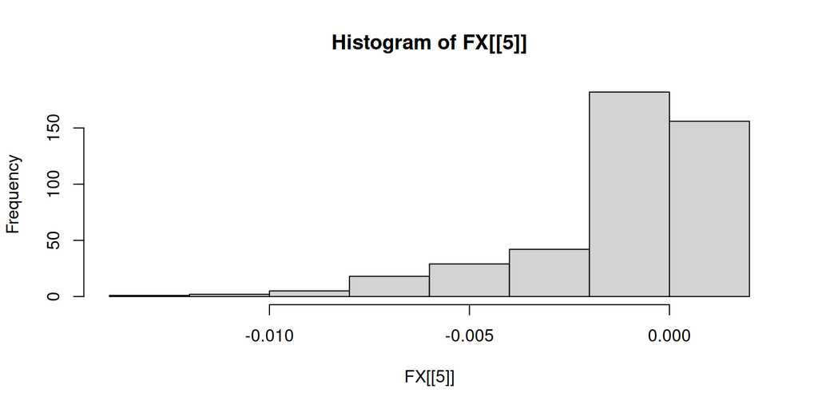

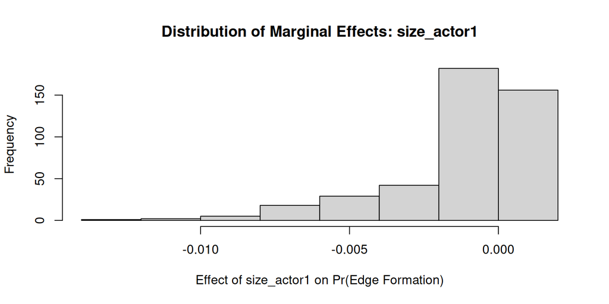

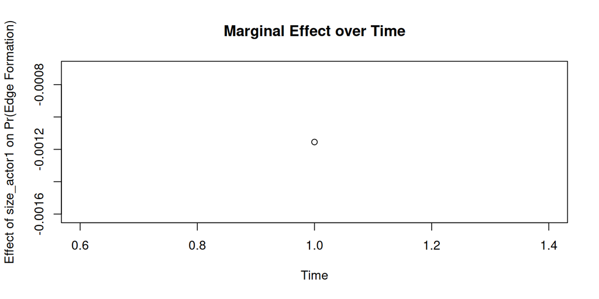

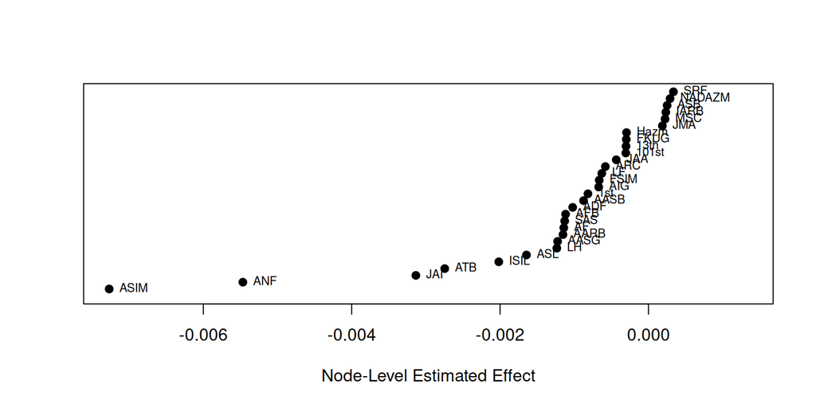

```r
plot(blocks_5, type = "effect", FX = fx)
```

**The block-level picture.** `plot()` on the fit (default `type = "groups"`) draws the blocks as a network of their own. Nodes are blocks, edge shade is tie probability, self-loops are the diagonal of the matrix you read via `plogis()` above; other types are `"blockmodel"`, `"membership"`, and `"hmm"` (for dynamic fits):

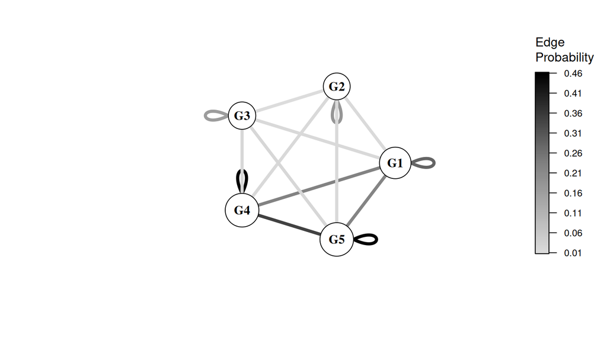

```r
set.seed(6886)
plot(blocks_5)
```

# 20 The spine: additive, discrete, continuous

Step back to the map one last time. These three families all represent dependence through latent actor structure, but their terms enter the **conditional mean or link**, not a generic variance bucket. Write $\eta_{ij}$ for that conditional linear predictor:

$$\mathbb E(Y_{ij}\mid x,z,u,v,a,b) = g^{-1}(\eta_{ij}),
\qquad
\eta_{ij}=\beta^{\top}x_{ij}+h_{ij},$$

There are three alternative building blocks for $h_{ij}$:

$$h_{ij} =
\begin{cases}
a_i+b_j, & \text{additive actor effects: SRM},\\
\alpha_{z_i z_j}, & \text{discrete latent types: blockmodel},\\
\gamma(u_i,v_j), & \text{continuous latent geometry: distance/factor}.
\end{cases}$$

For a binary blockmodel, $\alpha_{ab}=\operatorname{logit}(\theta_{ab})$; $\theta_{ab}$ itself is a probability, so it should not be added directly to a linear predictor. These are three answers to one question, *what latent actor structure makes dyads involving the same actors dependent after we average over that structure?* They differ in its shape:

- **Additive (SRM):** each actor gets a sender offset $a_i$ and a receiver offset $b_i$ in a directed network. They apply across all partners, so they cannot say *who* an actor over-trades with.
- **Discrete latent (blocks):** each actor is one of $K$ **types** ($z_i$). It can capture that Brazil trades with *this* set of countries, as long as “this set” is a block. Forces every actor into a type.
- **Continuous latent (distance/factor):** each actor is a **point in space** (or separate sender and receiver positions, $u_i$ and $v_i$). Nearby or similarly positioned actors can behave alike without a hard boundary.

Conditional on the latent actor effects, the models above treat distinct unordered dyads as independent. The directed SRM may still correlate the two observations inside one reciprocal pair through $\rho$. After we average over the unobserved actor effects, dyads that share actors become dependent. The SRM’s variance and covariance parameters describe the distribution of $a_i$ and $b_i$; they are not where the block matrix or latent geometry “lives.”

The two limits you watched today are the same limit at two granularities. The SRM gave each actor sender and receiver offsets and could not say who it connected to; the blockmodel gives each actor a *type* and can only say who it connects to as far as the type boundaries allow. Both are coarse descriptions of an actor’s *position*, and tomorrow refines the position itself: first as a location in a metric space (distance), then as a set of continuous latent factors (the eigenmodel/AME). Tomorrow does not take the verdict between those two on faith: we put the distance model on trial, we generate networks where it should work and networks where the triangle inequality says it cannot, and let the eigenvalues deliver the verdict.

(One cell sits between today and tomorrow on the map: the degree-corrected SBM from the Section 19 verdict callout, discrete roles with a continuous per-actor activity dial.)

Here is tomorrow written down, so you recognize it when you see it:

$$y_{ij} \;=\; \beta^{\top} x_{ij} + a_i + b_j
\;+\; \underbrace{\gamma(u_i, v_j)}_{\text{tomorrow: } u_i \text{ a point, not a box}}
\;+\; \varepsilon_{ij}.$$

Nothing today is discarded. The SRM’s $a_i + b_j$ becomes the additive part of Day 3’s AME model; the blockmodel remains the discrete alternative that tomorrow’s factor model can approximate with continuous positions. The ERGM on Day 4 takes a genuinely different route: it models the joint graph distribution with local structural statistics rather than making dyads conditionally independent given latent actor features. Same dependence, different representation.

## 20.1 After the Models Run: Turn Dependence Into a Political Result

Do not report the SRM as a longer regression table and the blockmodel as a list of numbered groups. The political result comes from explaining what each model changed about the story.

For the **SRM**, move through the output in this order:

1. State the covariate association after accounting for persistent sender and receiver propensities and within-pair reciprocity.
2. Report whether sender heterogeneity, receiver heterogeneity, generalized reciprocity, and dyadic reciprocity are substantively large and uncertain.
3. Use actor effects to identify cases worth explaining, but remember that these are model-based deviations, not fixed traits or causal effects.
4. Check whether simulated networks reproduce the degree, reciprocity, and other features needed for the claim.

For the **blockmodel**, ignore the arbitrary block numbers. Describe the fitted mixing profiles: which kinds of actors connect to which other kinds, whether the pattern is assortative, core-periphery, or disassortative, and how uncertain the memberships are. Then name what the block structure misses. If degree fit is poor, the problem may be within-block activity heterogeneity rather than a failure of relational types altogether.

**TipA human version of the SRM result**

“Once persistent exporter and importer propensities are represented, the estimated association for shared IGO memberships changes sign. The naive regression was therefore partly comparing which states appeared in a dyad rather than comparing otherwise similar dyads. The fitted actor effects also show substantial heterogeneity in states’ general tendencies to send and receive trade. We interpret the IGO coefficient as a dependence-adjusted association, not as a causal effect of institutional overlap.”

**TipA human version of the blockmodel result**

“The fitted blocks recover distinct trade-mixing profiles, but they do not fully reproduce the concentration of trade among especially active states. The political takeaway is evidence of relational types alongside meaningful within-type differences, not a claim that every state belongs to one natural geopolitical camp.”

The final paragraph in a paper should contain the substantive pattern, the dependence adjustment that changed or qualified it, the diagnostic evidence, and the inferential limit. A tour of every coefficient makes the result harder, not easier, to understand.

# 21 Your turn, part two

**TipExercises**

Start the core exercise in class and finish the rest tonight.

**Core (everyone).** Re-run the planted-partition recovery in Section 14, but make the blocks harder to tell apart: set the within-block probability to 0.25 and the between-block probability to 0.15 (instead of 0.45 and 0.05). Refit, and report the recovered $K$ and the confusion table. Does ICL still find three blocks? What does the soft membership matrix look like when the blocks blur?

**Stretch.** Build a **disassortative** network, two blocks that tie to *each other* but not to themselves, $\theta = \left(\begin{smallmatrix} .05 & .6 \\ .6 & .05 \end{smallmatrix}\right)$, using the `sim_sbm_binary` helper. Run Louvain and the blockmodel on it. Show that Louvain’s modularity is near zero (or negative) while the blockmodel recovers the two blocks, and write one sentence on why “these two groups avoid each other” is invisible to a method built to reward within-group density.

**Your data (take home).** Fit a blockmodel to your own network (`BM_bernoulli` for binary ties, `BM_gaussian` for weighted). Report the ICL-selected $K$, look at the membership, and, most importantly, run the GOF simulation from Section 18. Is the discrete story a good bet for your data, or is the actor-heterogeneity statistic telling you the model is missing an activity knob (Section 19)?

**Solutions, open after you’ve tried them**

```r
## Core: blurrier blocks
set.seed(6886)
theta_blur <- matrix(0.15, 3, 3); diag(theta_blur) <- 0.25
A_blur <- sim_sbm_binary(z_true, theta_blur)
fb <- BM_bernoulli("SBM_sym", A_blur, verbosity = 0, plotting = "")
fb$estimate()
which.max(fb$ICL)                       # May now prefer 1 or 2 blocks
Kb <- which.max(fb$ICL)
table(truth = z_true, est = apply(fb$memberships[[Kb]]$Z, 1, which.max))
# The lesson: recovery is not free. When within- and between-block
# probabilities get close, the signal-to-noise falls and ICL will
# happily tell you there are FEWER blocks than you planted, because at
# that separation the extra blocks genuinely do not pay for themselves.
# The soft memberships spread toward uniform, the same "I can't sort
# these" signal the Gade data gave us. A blockmodel that can't find
# blocks is doing its job; it's the honest answer.

## Stretch: disassortative
set.seed(6886)
z_da <- rep(1:2, each = 30)
theta_da <- matrix(c(0.05, 0.60, 0.60, 0.05), 2, 2)
A_da <- sim_sbm_binary(z_da, theta_da)
g_da <- graph_from_adjacency_matrix(A_da, mode = "undirected", diag = FALSE)
cluster_louvain(g_da)                    # Invents ~5 spurious communities
modularity(g_da, membership = z_da)      # The TRUE split: near zero / negative
fd <- BM_bernoulli("SBM_sym", A_da, verbosity = 0,
                   plotting = "", explore_min = 2)
fd$estimate()
table(truth = z_da,
      est = apply(fd$memberships[[which.max(fd$ICL)]]$Z, 1, which.max))
# Modularity is defined as (within-group edges) minus (expected within-
# group edges). Here there are almost NO within-group edges by design,
# so modularity is near zero or negative for the true split, Louvain
# reads "these two groups avoid each other" as "no community structure."
# The blockmodel doesn't privilege the diagonal of theta, so it recovers
# the two blocks and the off-diagonal theta names the avoidance directly.

## Your own network
# A <- <your n x n adjacency matrix, diag set to 0, no NAs>
# fit <- BM_bernoulli("SBM_sym", A); fit$estimate()   # Or BM_gaussian
# K <- which.max(fit$ICL)
# z <- apply(fit$memberships[[K]]$Z, 1, which.max)
# Then reuse sim + calc_gof from the gof section to get your actor_sd
# z-score. If it's above ~3, your fitted sbm is missing per-actor
# activity, which, per the scorecard, is not the same thing as
# "discreteness is wrong." Two fixes exist: the discrete one is a
# degree-corrected SBM (Karrer & Newman 2011, still boxes;
# implementations live mostly in Python's graph-tool), the continuous
# one is Day 3's latent geometry. Bring your network to both and compare.
```

**NoteExtra practice: raw versus residualized trade (do it tonight)**

In Section 17 we partialled distance out before fitting. Refit the Gaussian SBM on the *raw* `trade` matrix (skip the residualizing step) and compare the block membership to the one we got. Which countries change blocks, and does the story get more or less about geography?

**Solution**

```r
yRaw <- acast(trade, Var1 ~ Var2, value.var = "trade"); diag(yRaw) <- 0
set.seed(6886)
fr <- BM_gaussian("SBM", yRaw, verbosity = 0, plotting = "")
fr$estimate()
zr <- apply(fr$memberships[[which.max(fr$ICL)]]$Z, 1, which.max)
names(zr) <- rownames(yRaw)
table(residualized = z_tr, raw = zr)
# On the raw matrix, more of the block structure is really distance:
# neighbors trade more, so nearby countries clump. Residualizing first
# is a modeling choice that says, "I already know geography matters. Now
# show me the blocks in what's LEFT." Neither is wrong; they answer
# different questions, and you should say which one you asked.
```

# 22 What we did not show

Like the reading list, this is reference material. The collapsible “full toolbox” asides (in Section 10, Section 17, and Section 19) cover the rest of the day’s fitted-object surface; beyond those, here is what today deliberately did not demonstrate, and where it lives:

- **`plot(fit)` / `autoplot(fit)` on a lame fit**, one composite panel of trace, effects, and GOF. We used `trace_plot()`, `ab_plot()`, and `gof_plot()` separately so each read got its own beat; the composite is the quick-look version.
- **`uv_plot()` and `latent_positions()`**, empty today because every fit used `R = 0`. They are Day 3’s whole subject.
- **The other `ame()` families**, `"ordinal"`, `"poisson"`, `"cbin"`, and `"frn"` (those last two are censored and fixed-rank nomination designs, think “name up to five friends” surveys, and need the `odmax` argument). The syntax change is exactly the `family = "binary"` switch you saw in Section 7; see `?ame` for the family-by-mode support table.
- **`method = "als"` and `bootstrap =`**, an MCMC-free point estimator with bootstrap intervals, for when your network is big enough that the sampler hurts. See `?ame`.
- **`lame()`**, the longitudinal generalization of everything this morning (one network per period, dynamic effects). See `?lame` once you have repeated observations. Its long-run bookkeeping, `checkpoint_path =` plus `lame_resume()` to pick up an interrupted sampler, lives there too.
- **`combine_ame_chains()`**, pools multi-chain output into one fit; the Section 6 collapsible deliberately kept the chains *separate* (`combine_method = "list"`) so `compute_mcmc_diagnostics()` could compare them.
- **`el2sm()` / `sm2el()` / `design_array()`**, lame’s own edgelist-to-sociomatrix converters and covariate-array builder. `netify`’s `to_lame()` did those jobs for us on Day 1, which is why you never saw them.
- **`blockmodels` families we skipped**, `BM_poisson` for counts, `BM_bernoulli_covariates` for binary-with-covariates (the Gaussian version is in the Section 17 toolbox), `BM_bernoulli_multiplex` for two networks jointly, and the `"LBM"` model type for bipartite networks (see the shipped `blockmodels_vignette.pdf`).
- **Dynamic mixed-membership**, `mmsbm(..., timeID = )` fits a hidden-Markov version for longitudinal dyads; `plot(fit, "hmm")` shows the regime path. The initialization overrides (`fixed_mm`, `mm_init_t`, `init_gibbs` in `mmsbm.control`) are documented in `?mmsbm`.
- **The `sbm` package**, deliberately absent, per the warning at the top of this document: on our matrices its C++ solver can kill the whole R session.
- **Degree-corrected SBMs**, named in the Section 19 verdict callout as the discrete fix for the activity miss; implementations live mostly in Python’s graph-tool.

# 23 Reading

For the SRM half:

- Back & Kenny (2010), “The Social Relations Model: How to Understand Dyadic Processes,” *Social and Personality Psychology Compass*. Short, and the source of the decomposition. (Not shipped in this folder, it is a two-minute find online.)
- Minhas, Dorff, Gallop, Foster, Liu, Tellez & Ward (2022), “Taking Dyads Seriously,” *PSRM*, `minhas_etal_2022.pdf`, shipped in this folder. Sections 1 through 4 are for today. Figure 7 is the sender effects plot referenced in Section 7; it is the best argument in the paper that these are substantively readable quantities.

For the blockmodel half:

- Abbe (2018), “Community Detection and Stochastic Block Models: Recent Developments,” *JMLR*. The first half is the community-detection view you came in with, the second half is the SBM view we built today, and the paper is precisely about the bridge between them.
- Holland, Laskey & Leinhardt (1983), “Stochastic Blockmodels: First Steps,” *Social Networks*, the origin of the generative story in Section 12.
- Karrer & Newman (2011), “Stochastic Blockmodels and Community Structure in Networks,” *Physical Review E*, the degree-corrected SBM, the discrete answer to the actor-heterogeneity miss in Section 19.
- Newman (2016), “Equivalence Between Modularity Optimization and Maximum Likelihood Methods for Community Detection,” *Physical Review E*, the result quoted in the scope note of Section 11: modularity maximization is a frozen special case of SBM maximum likelihood.
- Gade, Gabbay, Hafez & Kelly (2019), “Networks of Cooperation: Rebel Alliances in Fragmented Civil Wars,” *Journal of Conflict Resolution*, the data behind the Section 19 scorecard.
- Léger (2016), “Blockmodels: An R Package for Estimating in Latent Block Model and Stochastic Block Model, With Various Probability Functions, With or Without Covariates,” the software reference for everything we fit today. (The file `blockmodels_vignette.pdf` that ships in this folder is a printout of the package’s worked examples, “simple and bipartite stochastic block models,” not the paper itself.)

**NoteAppendix: if the Bayesian vocabulary is new**

We have been saying “posterior mean” and “95% credible interval” without much ceremony. If that language is unfamiliar, work through `bayes_aside/bayes_workflow_code/Bayesian_Workflow_Example.Rmd` tonight (the `bayes_aside/` folder ships alongside this document, and includes a rendered HTML so you can read it without running anything), it covers priors, posteriors, and what a credible interval means as opposed to a confidence interval. The two short PDFs in the same folder are gentler still if you want the high-level story first.

The practical translation for this course: `est` is the mean of the posterior draws in `fit$BETA`, and `lo`/`hi` are the 2.5th and 97.5th percentiles of those same draws. Nothing is being inverted or asymptotically approximated. You can compute them yourself:

```r
round(t(apply(srm$BETA, 2, function(x)
  c(est = mean(x), lo = quantile(x, .025), hi = quantile(x, .975)))), 3)
```

**NoteAppendix: extracting a `blockmodels` fit**

The object `blockmodels` returns is a reference class, and its innards are nested lists indexed by the number of blocks. The three things you reach for:

```r
K   <- which.max(fit$ICL)                 # ICL-preferred block count
Z   <- fit$memberships[[K]]$Z             # n x K soft memberships
z   <- apply(Z, 1, which.max)             # Hard label per actor
# Block-connectivity: $pi for bernoulli, $mu (+ $sigma2) for gaussian
fit$model_parameters[[K]]
```

Always index by `which.max(fit$ICL)`, never by a literal `5`. The ICL peak moves when you change the data, residualize a covariate out, say, and the preferred $K$ shifts, and hard-coding the number is how the slides and the code silently drift apart.